# Introdución a RNA-seq

Ana BVA, Rodolfo

24 March 2021

Este documento encontrarás el código que se ocupará en el mini curso de RNA-seq, el código usado para generar las slides las puedes encontrar en Github.

# Flujo general de trabajo

En este mini curso veremos brevemente como analizar datos de RNA-seq, tendremos una breve introdución a RNA-seq, así como los pasos a seguir en el análisis bioinformático (como se observa en el diagrama).

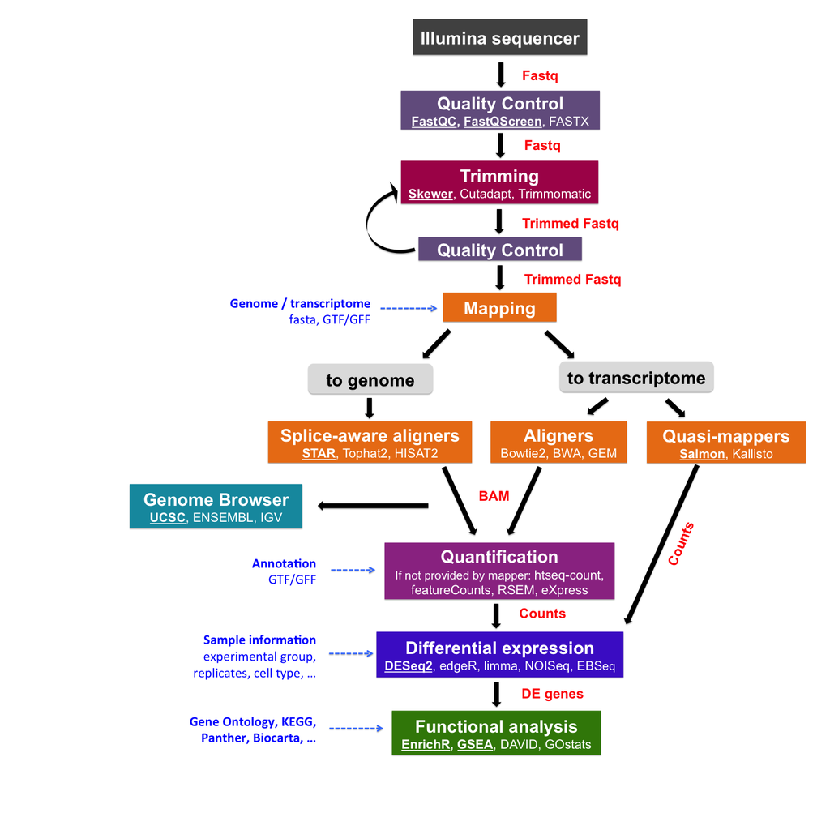

```r
knitr::include_graphics("https://biocorecrg.github.io/RNAseq_course_2019/images/RNAseq_workflow.png")
```

Imagen tomada de [BiCore RNAseq course 2019](https://biocorecrg.github.io/RNAseq_course_2019/salmon.html)

# 7-QC

## Pasos para installar FastQC:

1- Descargar el programa de su página web [fastQC](https://www.bioinformatics.babraham.ac.uk/projects/download.html#fastqc)

2- Hacer el archivo ejecutable

```bash
# chmod 755 /Applications/FastQC.app/Contents/MacOS/fastqc
ls -l /Applications/FastQC.app/Contents/MacOS/fastqc
```

```
## -rwxr-xr-x@ 1 user  admin  14998 Jan  8  2020 /Applications/FastQC.app/Contents/MacOS/fastqc
```

3- Crear una liga simbolica para ejecutar `fastqc` desde cualquier ubicación

```bash
ln -s /Applications/FastQC.app/Contents/MacOS/fastqc /usr/local/bin/fastqc
```

4- Correr `fastqc`

```bash
fastqc --help
```

```
##
##             FastQC - A high throughput sequence QC analysis tool
##
## SYNOPSIS
##
##  fastqc seqfile1 seqfile2 .. seqfileN
##
##     fastqc [-o output dir] [--(no)extract] [-f fastq|bam|sam]
##            [-c contaminant file] seqfile1 .. seqfileN
##
## DESCRIPTION
##
##     FastQC reads a set of sequence files and produces from each one a quality
##     control report consisting of a number of different modules, each one of
##     which will help to identify a different potential type of problem in your
##     data.
##
##     If no files to process are specified on the command line then the program
##     will start as an interactive graphical application.  If files are provided
##     on the command line then the program will run with no user interaction
##     required.  In this mode it is suitable for inclusion into a standardised
##     analysis pipeline.
##
##     The options for the program as as follows:
##
##     -h --help       Print this help file and exit
##
##     -v --version    Print the version of the program and exit
##
##     -o --outdir     Create all output files in the specified output directory.
##                     Please note that this directory must exist as the program
##                     will not create it.  If this option is not set then the
##                     output file for each sequence file is created in the same
##                     directory as the sequence file which was processed.
##
##     --casava        Files come from raw casava output. Files in the same sample
##                     group (differing only by the group number) will be analysed
##                     as a set rather than individually. Sequences with the filter
##                     flag set in the header will be excluded from the analysis.
##                     Files must have the same names given to them by casava
```

[output cut: 67 more lines]

```
##                     module. Specified Kmer length must be between 2 and 10. Default
##                     length is 7 if not specified.
##
##    -q --quiet       Supress all progress messages on stdout and only report errors.
##
##    -d --dir         Selects a directory to be used for temporary files written when
##                     generating report images. Defaults to system temp directory if
##                     not specified.
##
## BUGS
##
##     Any bugs in fastqc should be reported either to simon.andrews@babraham.ac.uk
##     or in www.bioinformatics.babraham.ac.uk/bugzilla/
##
##
```

## Pasos para correr FastQC:

1- Checar los datos fastq

```bash
pwd
ls data/Archivos_fastq
```

```
## /Users/user/Documents/Doctorado/Courses/Taught/minicurso_abr_2021
## s1_R1.fastq.gz
## s1_R2.fastq.gz
## s2_R1.fastq.gz
## s2_R2.fastq.gz
## s3_R1.fastq.gz
## s3_R2.fastq.gz
## s4_R1.fastq.gz
## s4_R2.fastq.gz
## s5_R1.fastq.gz
## s5_R2.fastq.gz
## s6_R1.fastq.gz
## s6_R2.fastq.gz
```

2- Crear un directorio para guardar el output

```bash
mkdir output/QC
```

3- Correr `FastQC`

```bash
# la opción -o es para elejir el directorio de salida
fastqc data/Archivos_fastq/*.fastq.gz -o output/QC/
```

4- Checar los archivos generados

```bash
ls output/QC
```

```
## multiqc_data
## multiqc_report.html
## s1_R1_fastqc.html
## s1_R1_fastqc.zip
## s1_R2_fastqc.html
## s1_R2_fastqc.zip
## s2_R1_fastqc.html
## s2_R1_fastqc.zip
## s2_R2_fastqc.html
## s2_R2_fastqc.zip
## s3_R1_fastqc.html
## s3_R1_fastqc.zip
## s3_R2_fastqc.html
## s3_R2_fastqc.zip
## s4_R1_fastqc.html
## s4_R1_fastqc.zip
## s4_R2_fastqc.html
## s4_R2_fastqc.zip
## s5_R1_fastqc.html
## s5_R1_fastqc.zip
## s5_R2_fastqc.html
## s5_R2_fastqc.zip
## s6_R1_fastqc.html
## s6_R1_fastqc.zip
## s6_R2_fastqc.html
## s6_R2_fastqc.zip
```

## MultiQC

[MultiQC](https://multiqc.info/) te permite juntar los output en un solo archivo y poder visualizarlos mejor.

*Esta parte es opcional, pero si trabajas con RNA-seq te puede intersar.

1. La instalación se hace con conda, así que primero activamos un ambiente conda

```bash
conda activate base
pip install multiqc
```

2. Correr MultiQC

```bash
cd output/.
multiQC .
```

3. Checar el output.html

# 8-Alineadores

## Generar índice del transcriptoma

Para ello vamos a requerir:

- Archivo **Fasta** del transcriptoma de referencia del humano. Descargado del sitio de [GeneCode](https://www.gencodegenes.org/human/). Lo pueden encontrar en el folder de `Transcriptome/`

Código para genear el índice

`-t`: Ubicación al archivo Fasta del transcriptoma

`-i`: Ubicación para salvar el índice

`--genecode`: El Fasta del transcriptoma de referencia está en formato de GENECODE

```bash
salmon index -t ../transcriptome/gencode.v37.transcripts.fa.gz -i ../transcriptome/genecode.v37.salmon141 -p 6
```

## Cuantificar la abundancia de los transcritos

Requerimientos:

- Archivos **Fastq** de las lecturas -> Paired end R1 y R2

Ubicados en el folder de `data`

- Índice generado en el paso anterior

Código para producir cuantificar los transcritos

`-i`: Ubicación del índice

`-l`: Tipo de librería

`-1 y -2`: Ubicación a las lecturas R1 y R2

`-o`: Ubicación para almacenar los resultados

```bash
##Crear un directorio para almacenar los datos de los conteos
mkdir -p ../salmon_quant
##Llamar salmon para realizar el conteo
salmon quant -i ../transcriptome/genecode.v37.salmon141 \
             -l A \
             -1 ../Data/s1_R1.fastq.gz -2 ../Data/s1_R2.fastq.gz \
             -p 6 --validateMappings \
             -o ../salmon_quant/s1_quant
```

# 9-Tximeta

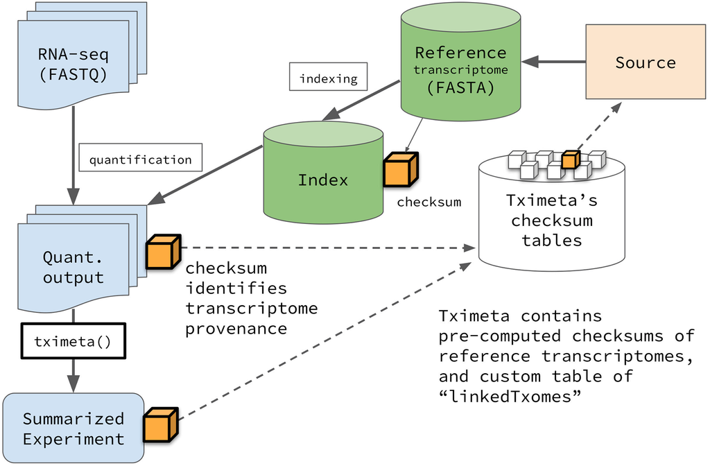

```r
knitr::include_graphics("https://journals.plos.org/ploscompbiol/article/figure/image?size=large&id=10.1371/journal.pcbi.1007664.g001")
```

[Love, Michael I., et al. “Tximeta: Reference sequence checksums for provenance identification in RNA-seq.” PLoS computational biology 16.2 (2020): e1007664.](https://journals.plos.org/ploscompbiol/article?id=10.1371/journal.pcbi.1007664)

## Instalación de tximeta

Instalar `tximeta` desde R usando `BiocManager`

```r
if (!requireNamespace("BiocManager", quietly = TRUE))
    install.packages("BiocManager")

BiocManager::install("tximeta")
```

## Importar datos

Utilizamos `tximeta` para importar los datos.

Nota: `tximeta` espera dos columnas:

- `files`: con la rut a `quant.sf`
- `names`: con los nombres de las muestras

Importamos la información de cada muestra

```r
# Leemos los datos
samples <- read.delim(here::here("output/salmon_quants/metadata.txt"))

# Generamos la columna "names"
samples$names <- samples$Unique_id
samples
```

```
##   Sample Cell Condition Replicate Unique_id     names
## 1     s1    A        CT         1    A_CT_1    A_CT_1
## 2     s2    A        CT         2    A_CT_2    A_CT_2
## 3     s3    A        CT         3    A_CT_3    A_CT_3
## 4     s4    A     Veraf         1 A_Veraf_1 A_Veraf_1
## 5     s5    A     Veraf         2 A_Veraf_2 A_Veraf_2
## 6     s6    A     Veraf         3 A_Veraf_3 A_Veraf_3
```

Ahora las cuentas generadas por `Salmon`

```r
# Ubicamos el dir de trabajo
dir <- file.path(here::here("output/salmon_quants"))
#Checamos que esten los folders
list.files(dir)
```

```
## [1] "metadata.txt" "s1_quant"     "s2_quant"     "s3_quant"     "s4_quant"
## [6] "s5_quant"     "s6_quant"
```

```r
# Que hacemos aqui??  Checar
# file.path(dir,paste0(info$Sample,"_quant"),"quant.sf")
samples$files <- file.path(dir,paste0(samples$Sample,"_quant"),"quant.sf")

#Checamos que los archivos existan
data.frame(samples$Sample, file.exists(samples$files))
```

```
##   samples.Sample file.exists.samples.files.
## 1             s1                       TRUE
## 2             s2                       TRUE
## 3             s3                       TRUE
## 4             s4                       TRUE
## 5             s5                       TRUE
## 6             s6                       TRUE
```

Importar los datos usando `tximeta`

```r
#BiocManager::install("tximeta")
library(tximeta)
samples
```

```
##   Sample Cell Condition Replicate Unique_id     names
## 1     s1    A        CT         1    A_CT_1    A_CT_1
## 2     s2    A        CT         2    A_CT_2    A_CT_2
## 3     s3    A        CT         3    A_CT_3    A_CT_3
## 4     s4    A     Veraf         1 A_Veraf_1 A_Veraf_1
## 5     s5    A     Veraf         2 A_Veraf_2 A_Veraf_2
## 6     s6    A     Veraf         3 A_Veraf_3 A_Veraf_3
##                                                                                                      files
## 1 /Users/user/Documents/Doctorado/Courses/Taught/minicurso_abr_2021/output/salmon_quants/s1_quant/quant.sf
## 2 /Users/user/Documents/Doctorado/Courses/Taught/minicurso_abr_2021/output/salmon_quants/s2_quant/quant.sf
## 3 /Users/user/Documents/Doctorado/Courses/Taught/minicurso_abr_2021/output/salmon_quants/s3_quant/quant.sf
## 4 /Users/user/Documents/Doctorado/Courses/Taught/minicurso_abr_2021/output/salmon_quants/s4_quant/quant.sf
## 5 /Users/user/Documents/Doctorado/Courses/Taught/minicurso_abr_2021/output/salmon_quants/s5_quant/quant.sf
## 6 /Users/user/Documents/Doctorado/Courses/Taught/minicurso_abr_2021/output/salmon_quants/s6_quant/quant.sf
```

```r
se <- tximeta(samples)
```

```
## importing quantifications
```

```
## reading in files with read_tsv
```

```
## 1 2 3 4 5 6
## found matching transcriptome:
## [ GENCODE - Homo sapiens - release 37 ]
## loading existing TxDb created: 2021-03-04 03:17:23
##
##
##
##
## loading existing transcript ranges created: 2021-03-04 03:17:35
## fetching genome info for GENCODE
```

# 10-Summarized experiment

```r
library(SummarizedExperiment)
se
```

```
## class: RangedSummarizedExperiment
## dim: 233652 6
## metadata(6): tximetaInfo quantInfo ... txomeInfo txdbInfo
## assays(3): counts abundance length
## rownames(233652): ENST00000456328.2 ENST00000450305.2 ...
##   ENST00000387460.2 ENST00000387461.2
## rowData names(3): tx_id gene_id tx_name
## colnames(6): A_CT_1 A_CT_2 ... A_Veraf_2 A_Veraf_3
## colData names(6): Sample Cell ... Unique_id names
```

## ColData

El cajón o slot correspondiente a `ColData` contiene la tabla de metadatos creada para importar las cuentas con tximeta.

```r
colData(se)
```

```
## DataFrame with 6 rows and 6 columns
##                Sample        Cell   Condition Replicate   Unique_id       names
##           <character> <character> <character> <integer> <character> <character>
## A_CT_1             s1           A          CT         1      A_CT_1      A_CT_1
## A_CT_2             s2           A          CT         2      A_CT_2      A_CT_2
## A_CT_3             s3           A          CT         3      A_CT_3      A_CT_3
## A_Veraf_1          s4           A       Veraf         1   A_Veraf_1   A_Veraf_1
## A_Veraf_2          s5           A       Veraf         2   A_Veraf_2   A_Veraf_2
## A_Veraf_3          s6           A       Veraf         3   A_Veraf_3   A_Veraf_3
```

El slot **ColData** es un objeto con clase de *DataFrame*

```r
class(colData(se))
```

```
## [1] "DFrame"
## attr(,"package")
## [1] "S4Vectors"
```

```r
rownames(colData(se))
```

```
## [1] "A_CT_1"    "A_CT_2"    "A_CT_3"    "A_Veraf_1" "A_Veraf_2" "A_Veraf_3"
```

## rowRanges

El cajón de `rowRanges` hace referencia a las coordenadas de cada transcrito

```r
rowRanges(se)
```

```
## GRanges object with 233652 ranges and 3 metadata columns:
##                     seqnames      ranges strand |     tx_id           gene_id
##                        <Rle>   <IRanges>  <Rle> | <integer>   <CharacterList>
##   ENST00000456328.2     chr1 11869-14409      + |         1 ENSG00000223972.5
##   ENST00000450305.2     chr1 12010-13670      + |         2 ENSG00000223972.5
##   ENST00000488147.1     chr1 14404-29570      - |     10794 ENSG00000227232.5
##   ENST00000619216.1     chr1 17369-17436      - |     10795 ENSG00000278267.1
##   ENST00000473358.1     chr1 29554-31097      + |         3 ENSG00000243485.5
##                 ...      ...         ...    ... .       ...               ...
##   ENST00000361681.2     chrM 14149-14673      - |    234483 ENSG00000198695.2
##   ENST00000387459.1     chrM 14674-14742      - |    234484 ENSG00000210194.1
##   ENST00000361789.2     chrM 14747-15887      + |    234475 ENSG00000198727.2
##   ENST00000387460.2     chrM 15888-15953      + |    234476 ENSG00000210195.2
##   ENST00000387461.2     chrM 15956-16023      - |    234485 ENSG00000210196.2
##                               tx_name
##                           <character>
##   ENST00000456328.2 ENST00000456328.2
##   ENST00000450305.2 ENST00000450305.2
##   ENST00000488147.1 ENST00000488147.1
##   ENST00000619216.1 ENST00000619216.1
##   ENST00000473358.1 ENST00000473358.1
##                 ...               ...
##   ENST00000361681.2 ENST00000361681.2
##   ENST00000387459.1 ENST00000387459.1
##   ENST00000361789.2 ENST00000361789.2
##   ENST00000387460.2 ENST00000387460.2
##   ENST00000387461.2 ENST00000387461.2
##   -------
##   seqinfo: 25 sequences (1 circular) from hg38 genome
```

El cajón **rowRanges** almacena metadatos de cada secuencia (en este caso cromosomas)

```r
seqinfo(rowRanges(se))
```

```
## Seqinfo object with 25 sequences (1 circular) from hg38 genome:
##   seqnames seqlengths isCircular genome
##   chr1      248956422      FALSE   hg38
##   chr2      242193529      FALSE   hg38
##   chr3      198295559      FALSE   hg38
##   chr4      190214555      FALSE   hg38
##   chr5      181538259      FALSE   hg38
##   ...             ...        ...    ...
##   chr21      46709983      FALSE   hg38
##   chr22      50818468      FALSE   hg38
##   chrX      156040895      FALSE   hg38
##   chrY       57227415      FALSE   hg38
##   chrM          16569       TRUE   hg38
```

## Assay

El slot `assay` almacena la información de las cuentas para cada transcrito dividida en tres niveles:

```r
assayNames(se)
```

```
## [1] "counts"    "abundance" "length"
```

Para acceder a la matriz de cuentas estimadas por **Salmon**, correr:

```r
head(assay(se), 5)
```

```
##                   A_CT_1 A_CT_2 A_CT_3 A_Veraf_1 A_Veraf_2 A_Veraf_3
## ENST00000456328.2      0      0      0     1.411     0.000     0.000
## ENST00000450305.2      0      0      0     0.000     0.000     0.000
## ENST00000488147.1      0      0      0     2.912     6.353     2.818
## ENST00000619216.1      0      0      0     0.000     0.000     0.000
## ENST00000473358.1      0      0      0     0.000     0.000     0.000
```

Las matriz de abundancia *(TPM)* puede obtenerse:

```r
## Obtener matriz de TPM
head(se@assays@data$abundance, 5)
```

```
##                   A_CT_1 A_CT_2 A_CT_3 A_Veraf_1 A_Veraf_2 A_Veraf_3
## ENST00000456328.2      0      0      0  0.715302  0.000000  0.000000
## ENST00000450305.2      0      0      0  0.000000  0.000000  0.000000
## ENST00000488147.1      0      0      0  2.017645  4.231245  1.928893
## ENST00000619216.1      0      0      0  0.000000  0.000000  0.000000
## ENST00000473358.1      0      0      0  0.000000  0.000000  0.000000
```

## ¿Recuerdan a qué tiene que ser igual *Rownames* del slot colData?

```r
rownames(colData(se))
```

```
## [1] "A_CT_1"    "A_CT_2"    "A_CT_3"    "A_Veraf_1" "A_Veraf_2" "A_Veraf_3"
```

```r
## Comprobar que rownames de colData es igual a colnames de assay
row.names(colData(se)) == colnames(assay(se))
```

```
## [1] TRUE TRUE TRUE TRUE TRUE TRUE
```

# 11-Normalización

- Es el primer paso del análisis de expresión diferencial y es necesario para hacer comparaciones acertadas entre muestras.
- Las cuentas crudas están conformadas por un componente “interesante” (la expresión de RNA) y componentes “no interesantes” (como los batch effects, ruido de la plataforma, etc.).
- La normalzación escala las cuentas para tratar de reducir los componentes “no interesantes” y poder comparar las muestras entre si.

## Métodos comunes

| Método de normalización | Descripción | Factores de evaluación | Recomendaciones de uso |
| --- | --- | --- | --- |
| CPM (cuentas por millón): cuentas escalados por el número total de lecturas | profundidad de secuenciación | comparaciones de cuentas de genes entre réplicas del mismo grupo de muestras | NO para comparaciones dentro de la muestra o análisis de DE. |
| TPM (transcritos por kilobase por millón de lecturas): cuentas por longitud de transcripción (kb) por millón de lecturas mapeadas | profundidad de secuenciación y longitud de genes | comparaciones de cuentas de genes dentro de una muestra o entre muestras del mismo grupo de muestras | NO para análisis de DE. |
| RPKM/FPKM (lecturas/fragmentos por kilobase de exón por millón de lecturas/fragmentos mapeados | similar a TPM, profundidad de secuenciación y longitud del gen | comparaciones de cuentas entre genes dentro de una muestra | NO para comparaciones entre muestras o análisis de DE. |
| Factor de normalización de DESeq2 | cuentas divididas por factores de tamaño específicos de la muestra determinados por la mediana del ratio de cuentas de genes en relación con la media geométrica por gen | profundidad de secuenciación y composición del RNA | comparaciones de cuentas de genes entre muestras y para el análisis de DE; NO para comparaciones dentro de la muestra |
| La media cortada de los valores M de EdgeR (TMM) | utiliza una media recortada ponderada de los ratios de expresión logarítmica entre las muestras | profundidad de secuenciación | composición de RNA y longitud de los genes. |

[Tabla tomada de Intro to DGE](https://hbctraining.github.io/DGE_workshop/lessons/02_DGE_count_normalization.html)

## DESeq2

- Normalización para análisis de expresión diferencial:
  - Factor de normalización de `DESeq2`
- Normalización para visualización u otras aplicaciones:
  - Variance stabilizing transformation (VST)
  - Regularized-logarithm transformation (rlog)

`DESeq2`ajusta a un modelo lineal generalizado (GLM) de la familia binomial negativa (NB).

## Factor de normalización en DESeq2

Ejemplo de como se calcula el factor de normalización en DESeq2

```r
df <- tibble(gene = c("gene1", "gene2"),
                 muestraA = c(1749, 35),
                 muestraB = c(943, 29)
                 )
df
```

```
## # A tibble: 2 x 3
##   gene  muestraA muestraB
##   <chr>    <dbl>    <dbl>
## 1 gene1     1749      943
## 2 gene2       35       29
```

1. Crea una pseudo-referencia por muestra (promedio geometrico por fila) `sqrt(muestraA * mueestra B)`

```r
df <- df %>%
  rowwise() %>%
  mutate(prom_geom = sqrt(muestraA * muestraB))
df
```

```
## # A tibble: 2 x 4
## # Rowwise:
##   gene  muestraA muestraB prom_geom
##   <chr>    <dbl>    <dbl>     <dbl>
## 1 gene1     1749      943    1284.
## 2 gene2       35       29      31.9
```

2. Se calcula la fración `muestra/pseudo-referencia`

```r
df <- df %>%
  rowwise() %>%
  mutate(muestraA_pseudo_ref = muestraA / prom_geom) %>%
  mutate(muestraB_pseudo_ref = muestraB / prom_geom)

df
```

```
## # A tibble: 2 x 6
## # Rowwise:
##   gene  muestraA muestraB prom_geom muestraA_pseudo_ref muestraB_pseudo_ref
##   <chr>    <dbl>    <dbl>     <dbl>               <dbl>               <dbl>
## 1 gene1     1749      943    1284.                 1.36               0.734
## 2 gene2       35       29      31.9                1.10               0.910
```

3. Se calcula un factor de normalización (size factor) utilizando la `median` por columnas.

```r
norm_factor_muestraA <- median(df$muestraA_pseudo_ref)
norm_factor_muestraA
```

```
## [1] 1.230235
```

```r
norm_factor_muestraB <- median(df$muestraB_pseudo_ref)
norm_factor_muestraB
```

```
## [1] 0.8222689
```

4. Se dividen las `cuentas crudas/size factor` para calcular las cuentas normalizadas.

```r
df %>%
  select(gene, muestraA, muestraB)
```

```
## # A tibble: 2 x 3
## # Rowwise:
##   gene  muestraA muestraB
##   <chr>    <dbl>    <dbl>
## 1 gene1     1749      943
## 2 gene2       35       29
```

```r
df$norm_muestraA <- df$muestraA/norm_factor_muestraA
df$norm_muestraB <- df$muestraB/norm_factor_muestraB

df %>%
  select(norm_muestraA, norm_muestraB)
```

```
## # A tibble: 2 x 2
## # Rowwise:
##   norm_muestraA norm_muestraB
##           <dbl>         <dbl>
## 1        1422.         1147.
## 2          28.4          35.3
```

## Ejercicio

Se pueden ocupar otras transformaciones en la paquetería de `DESeq2`pero no son las mas recomendadas para DE.

Para normalizar, primero construimos el objeto `DESeqDataSet`, para ello necesitamos definir el modelo de DE (Quienes son Controles y quienes tratamiento).

```r
library("DESeq2")
library("dplyr")
library("ggplot2")
library("vsn")
```

```r
se$Condition <- factor(se$Condition)
table(se$Condition)
```

```
##
##    CT Veraf
##     3     3
```

```r
dds <- DESeqDataSet(se, design = ~ Condition)
```

```
## using counts and average transcript lengths from tximeta
```

```r
dds <- DESeq(dds)
```

```
## using 'avgTxLength' from assays(dds), correcting for library size
```

## Otras transformaciones

Puedes realizar otras transformaciones en `DESeq2` para estabilizar la varianza a través de los differentes valores promedio de expresión.

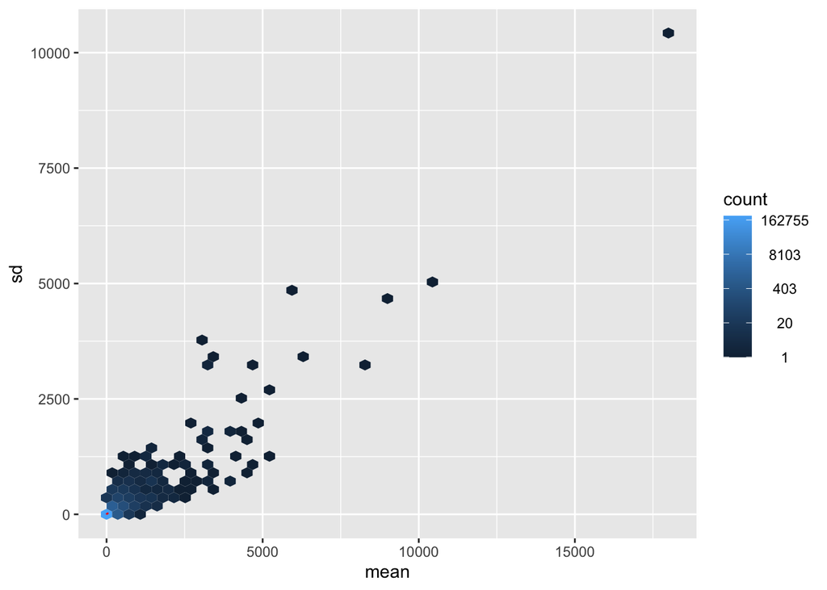

```r
meanSdPlot(counts(dds), ranks = F)
```

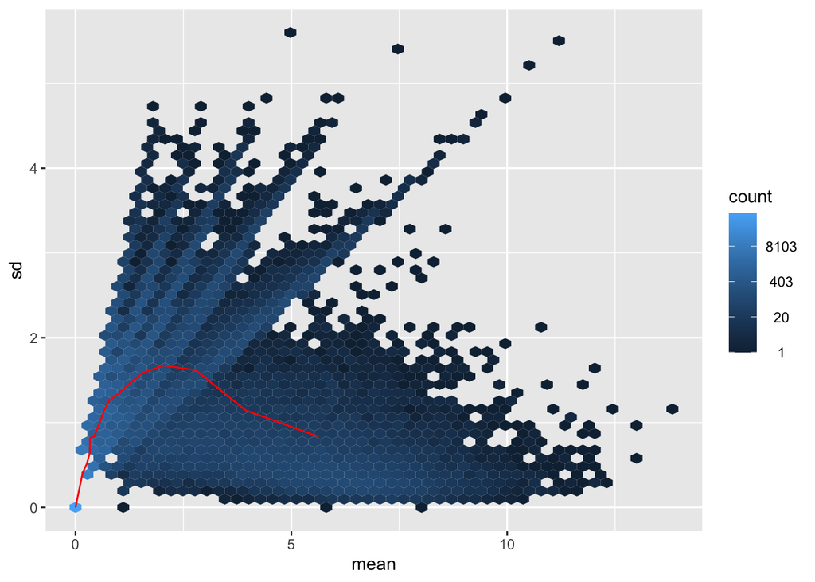

```r
meanSdPlot(log2(counts(dds) +1), ranks = F)
```

```r
# variance stabilizing transformation (VST), (Anders and Huber 2010)
vsd <- vst(dds, blind = FALSE)
head(assay(vsd), 3)
```

```
##                     A_CT_1   A_CT_2   A_CT_3 A_Veraf_1 A_Veraf_2 A_Veraf_3
## ENST00000456328.2 4.819827 4.819827 4.819827  5.087907  4.819827  4.819827
## ENST00000450305.2 4.819827 4.819827 4.819827  4.819827  4.819827  4.819827
## ENST00000488147.1 4.819827 4.819827 4.819827  5.288910  5.466548  5.277363
```

```r
# regularized-logarithm transformation (rlog), (Love, Huber, and Anders 2014)
rld <- rlog(dds, blind = FALSE)
head(assay(rld), 3)
```

```
##                       A_CT_1    A_CT_2     A_CT_3  A_Veraf_1 A_Veraf_2
## ENST00000456328.2 -1.9901456 -1.995442 -1.9960595 -1.7899302 -1.998401
## ENST00000450305.2  0.0000000  0.000000  0.0000000  0.0000000  0.000000
## ENST00000488147.1 -0.2316015 -0.229809 -0.2415125  0.8316449  1.290550
##                    A_Veraf_3
## ENST00000456328.2 -2.0006433
## ENST00000450305.2  0.0000000
## ENST00000488147.1  0.8007199
```

```r
dds <- estimateSizeFactors(dds)
```

```
## using 'avgTxLength' from assays(dds), correcting for library size
```

```r
df <- bind_rows(
  as_data_frame(log2(counts(dds, normalized=TRUE)[, 1:2]+1)) %>%
         mutate(transformation = "log2(x + 1)"),
  as_data_frame(assay(vsd)[, 1:2]) %>% mutate(transformation = "vst"),
  as_data_frame(assay(rld)[, 1:2]) %>% mutate(transformation = "rlog"))
```

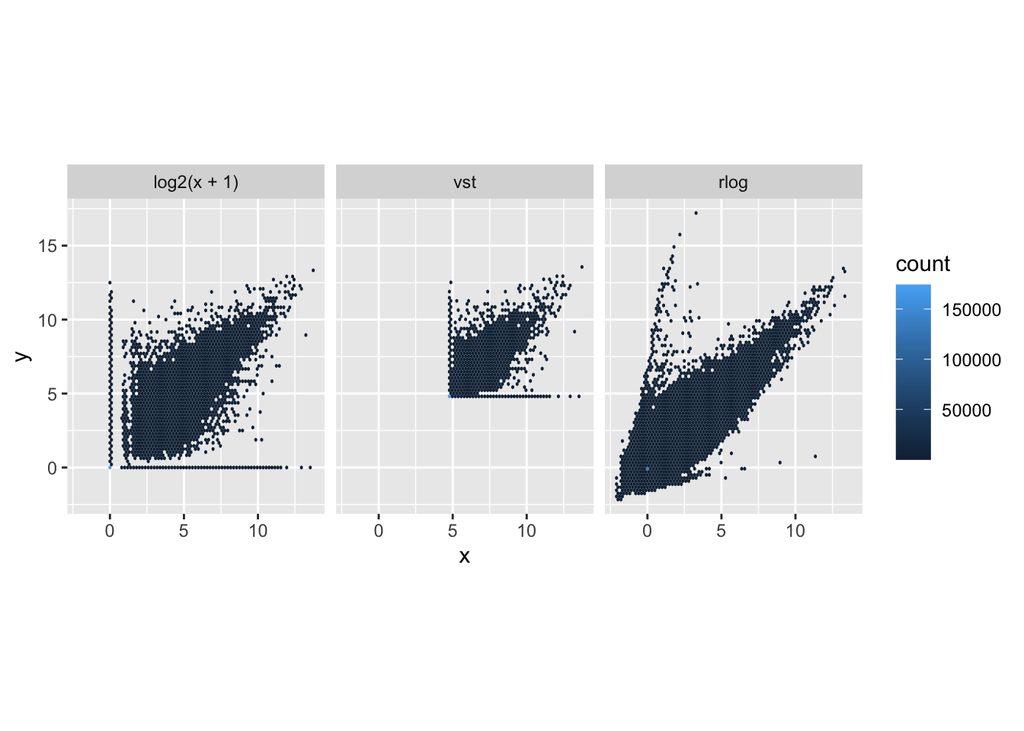

```r
colnames(df)[1:2] <- c("x", "y")

lvls <- c("log2(x + 1)", "vst", "rlog")
df$transformation <- factor(df$transformation, levels=lvls)

ggplot(df, aes(x = x, y = y)) + geom_hex(bins = 80) +
  coord_fixed() + facet_grid( . ~ transformation)
```

# 12-Exploración de datos

## PCA

- Análisis de componentes principales
- Método algebraico para reducir la dimensionalidad de sets de datos complejos (múltiples variables)
- Reducción de dimensionalidad o variables permite un análisis exploratorio más intuitivo
- Reducción de variables implica preservar y captar la mayor información sobre los datos

## ¿Cómo crear nuestro propio PCA?

Primero instalen las siguientes librerías:

```r
library(DESeq2)
library(PCAtools)
```

```r
## Transformación recomendada para sets de con menos de 30 muestras
rld <- rlog(dds, blind = F)
```

- Usemos la función interna de *DESeq2* para graficar nuestro PCA:

```r
## El argumento intgroup permite especificar mediante cuál variable colorear los datos
plotPCA(rld, intgroup = "Condition")
```

[output not shown]

- Con la librería de *PCAtools*:

```r
## Crear un objeto que contenga los datos del PCA
PCA <- pca(assay(rld), scale = T, metadata = colData(rld))
## Graficar en 2D los resultados
biplot(PCA, colby = "Condition")
## Generar un screeplot para visualizar la varianza asociada a cada componente
screeplot(PCA)
```

[output not shown]

## ¿Cómo ven los resultados?

[figure not shown]

```r
biplot(PCA, lab = colnames(assay(rld)), colby = "Condition", legendPosition = "right")
```

# 13-Análisis de expresión diferencial (DE)

Paso para obtener cuales son los genes que varían entre las condiciones

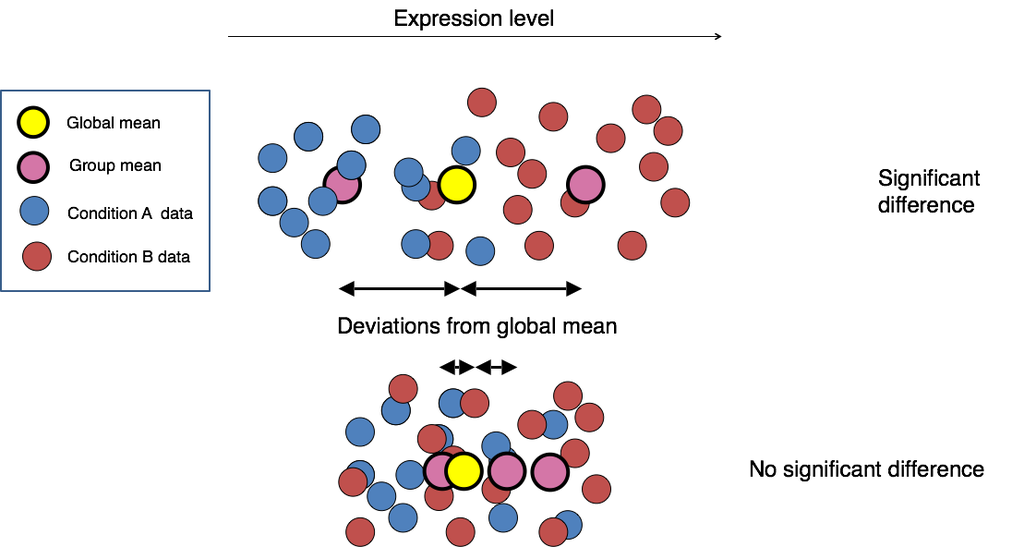

```r
knitr::include_graphics("https://raw.githubusercontent.com/hbctraining/DGE_workshop/master/img/de_theory.png")
```

[Imagen tomada de Intro to DGE](https://github.com/hbctraining/DGE_workshop)

```r
se$Condition <- factor(se$Condition)
table(se$Condition)
```

```
##
##    CT Veraf
##     3     3
```

```r
dds <- DESeqDataSet(se, design = ~ Condition)
```

```
## using counts and average transcript lengths from tximeta
```

```r
dds <- DESeq(dds)
```

```
## using 'avgTxLength' from assays(dds), correcting for library size
```

Para ver los resultados podemos usar la función `results`

```r
res <- results(dds)
res
```

```
## log2 fold change (MLE): Condition Veraf vs CT
## Wald test p-value: Condition Veraf vs CT
## DataFrame with 233652 rows and 6 columns
##                      baseMean log2FoldChange     lfcSE      stat    pvalue
##                     <numeric>      <numeric> <numeric> <numeric> <numeric>
## ENST00000456328.2    0.163001       0.886638   4.08047  0.217288 0.8279839
## ENST00000450305.2    0.000000             NA        NA        NA        NA
## ENST00000488147.1    1.941305       4.360949   2.58115  1.689537 0.0911167
## ENST00000619216.1    0.000000             NA        NA        NA        NA
## ENST00000473358.1    0.000000             NA        NA        NA        NA
## ...                       ...            ...       ...       ...       ...
## ENST00000361681.2  130.591245      -2.152010   1.55620 -1.382866        NA
## ENST00000387459.1    0.563650       2.815566   3.98968  0.705712  0.480367
## ENST00000361789.2 3264.504913       1.498563   1.14614  1.307488  0.191047
## ENST00000387460.2    0.263223       1.361711   4.03461  0.337507  0.735734
## ENST00000387461.2    1.528414       0.967883   2.86661  0.337640  0.735634
##                        padj
##                   <numeric>
## ENST00000456328.2        NA
## ENST00000450305.2        NA
## ENST00000488147.1        NA
## ENST00000619216.1        NA
## ENST00000473358.1        NA
## ...                     ...
## ENST00000361681.2        NA
## ENST00000387459.1        NA
## ENST00000361789.2  0.997749
## ENST00000387460.2        NA
## ENST00000387461.2        NA
```

```r
summary(res)
```

```
##
## out of 97645 with nonzero total read count
## adjusted p-value < 0.1
## LFC > 0 (up)       : 315, 0.32%
## LFC < 0 (down)     : 291, 0.3%
## outliers [1]       : 1011, 1%
## low counts [2]     : 73681, 75%
## (mean count < 7)
## [1] see 'cooksCutoff' argument of ?results
## [2] see 'independentFiltering' argument of ?results
```

Para ver que hay en cada columna:

```r
mcols(res, use.names = TRUE)
```

```
## DataFrame with 6 rows and 2 columns
##                        type            description
##                 <character>            <character>
## baseMean       intermediate mean of normalized c..
## log2FoldChange      results log2 fold change (ML..
## lfcSE               results standard error: Cond..
## stat                results Wald statistic: Cond..
## pvalue              results Wald test p-value: C..
## padj                results   BH adjusted p-values
```

Podemos hacer cortes:

```r
resLFC1 <- results(dds, lfcThreshold=1)
table(resLFC1$padj < 0.1)
```

```
##
## FALSE  TRUE
## 15802   282
```